# Modele Nieparametryczne

Igor Adamiec

1/30/2019

Do badania wykorzyształem zbiór danych **Auto** z pakietu **ISLR**. Znajdują się w nich dane dotyczace samochodow takie jak kontynent, rok produkcji, waga, przyspieszenie itd.

```r
library(tidyverse)
library(ISLR)
library(mgcv)
dataset <- Auto %>%
  mutate(origin = as.factor(origin))
```

```r
dataset %>% glimpse
```

```
## Observations: 392
## Variables: 9
## $ mpg          <dbl> 18, 15, 18, 16, 17, 15, 14, 14, 14, 15, 15, 14, 1...
## $ cylinders    <dbl> 8, 8, 8, 8, 8, 8, 8, 8, 8, 8, 8, 8, 8, 8, 4, 6, 6...
## $ displacement <dbl> 307, 350, 318, 304, 302, 429, 454, 440, 455, 390,...
## $ horsepower   <dbl> 130, 165, 150, 150, 140, 198, 220, 215, 225, 190,...
## $ weight       <dbl> 3504, 3693, 3436, 3433, 3449, 4341, 4354, 4312, 4...
## $ acceleration <dbl> 12.0, 11.5, 11.0, 12.0, 10.5, 10.0, 9.0, 8.5, 10....
## $ year         <dbl> 70, 70, 70, 70, 70, 70, 70, 70, 70, 70, 70, 70, 7...
## $ origin       <fct> 1, 1, 1, 1, 1, 1, 1, 1, 1, 1, 1, 1, 1, 1, 3, 1, 1...
## $ name         <fct> chevrolet chevelle malibu, buick skylark 320, ply...
```

```r
summary(dataset)
```

```
##       mpg          cylinders      displacement     horsepower
##  Min.   : 9.00   Min.   :3.000   Min.   : 68.0   Min.   : 46.0
##  1st Qu.:17.00   1st Qu.:4.000   1st Qu.:105.0   1st Qu.: 75.0
##  Median :22.75   Median :4.000   Median :151.0   Median : 93.5
##  Mean   :23.45   Mean   :5.472   Mean   :194.4   Mean   :104.5
##  3rd Qu.:29.00   3rd Qu.:8.000   3rd Qu.:275.8   3rd Qu.:126.0
##  Max.   :46.60   Max.   :8.000   Max.   :455.0   Max.   :230.0
##
##      weight      acceleration        year       origin
##  Min.   :1613   Min.   : 8.00   Min.   :70.00   1:245
##  1st Qu.:2225   1st Qu.:13.78   1st Qu.:73.00   2: 68
##  Median :2804   Median :15.50   Median :76.00   3: 79
##  Mean   :2978   Mean   :15.54   Mean   :75.98
##  3rd Qu.:3615   3rd Qu.:17.02   3rd Qu.:79.00
##  Max.   :5140   Max.   :24.80   Max.   :82.00
##
##                  name
##  amc matador       :  5
##  ford pinto        :  5
##  toyota corolla    :  5
##  amc gremlin       :  4
##  amc hornet        :  4
##  chevrolet chevette:  4
##  (Other)           :365
```

Na poniższym wykresie widzimy przyspieszenie w zaleznosci od ilosci koni mechanicznych.

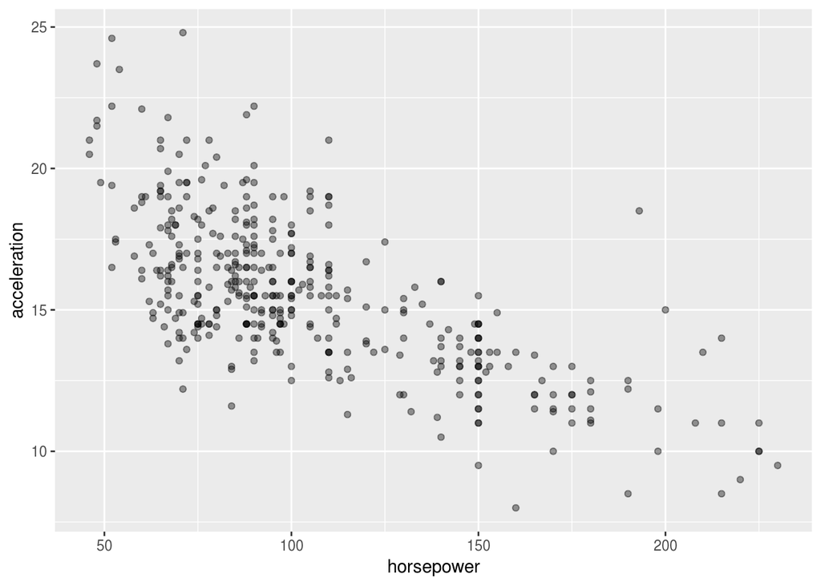

```r
dataset %>%
  ggplot() +
  geom_point(aes(x = horsepower, y = acceleration), alpha = .4)
```

# Wygladzanie

## Regresja wielomianowa

Wybralem wielomian stopnia 5 - do tego poziomu wszystkie parametry sa istotne. Potem zaczynaja tracic na istotnosci.

```r
wielomianowa <- lm(data = dataset,
                   formula = acceleration ~ poly(horsepower, 5, raw = T))
wielomianowa %>%
  summary
```

```
##
## Call:
## lm(formula = acceleration ~ poly(horsepower, 5, raw = T), data = dataset)
##
## Residuals:
##    Min     1Q Median     3Q    Max
## -4.700 -1.306 -0.091  1.101  7.942
##
## Coefficients:
##                                 Estimate Std. Error t value Pr(>|t|)
## (Intercept)                    8.541e+01  1.277e+01   6.689 7.92e-11 ***
## poly(horsepower, 5, raw = T)1 -2.908e+00  5.822e-01  -4.995 8.93e-07 ***
## poly(horsepower, 5, raw = T)2  4.788e-02  1.007e-02   4.756 2.80e-06 ***
## poly(horsepower, 5, raw = T)3 -3.810e-04  8.267e-05  -4.608 5.53e-06 ***
## poly(horsepower, 5, raw = T)4  1.444e-06  3.236e-07   4.461 1.07e-05 ***
## poly(horsepower, 5, raw = T)5 -2.091e-09  4.849e-10  -4.311 2.06e-05 ***
## ---
## Signif. codes:  0 '***' 0.001 '**' 0.01 '*' 0.05 '.' 0.1 ' ' 1
##
## Residual standard error: 1.933 on 386 degrees of freedom
## Multiple R-squared:  0.5154, Adjusted R-squared:  0.5091
## F-statistic: 82.09 on 5 and 386 DF,  p-value: < 2.2e-16
```

Przedstawienie modelu na wykresie:

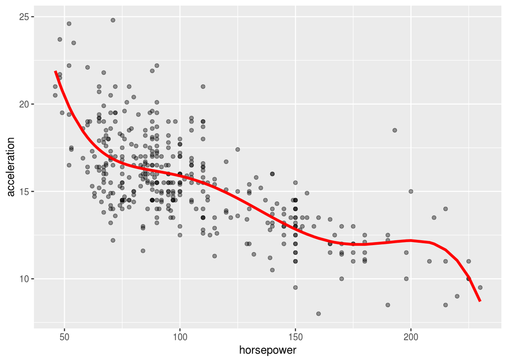

```r
dataset %>%
  ggplot() +
  geom_point(aes(x = horsepower, y = acceleration), alpha = .4) +
  geom_line(aes(x = horsepower, y = predict(wielomianowa)), color = "red", size = 1.3)
```

Z powodu dosc wysokiego stopnia wielomianu, widzimy ze model dostosowuje sie do danych rzeczywistych. Nie jest on jednak na tyle wysoki, by wystepowala chropowatosc wykresu.

# Generalized Additive Model

Zmienna origin zostala wczytana jako factor (1 - Ameryka, 2 - Europa, 3 - Japonia)

W modelu gam_1 zmiennymi wygladzanymi beda: - horsepower, - weight, - mpg (miles per gallon).

Zmienna czynnikowa bedzie tylko: - origin.

```r
gam_1 <- gam(data = dataset,
             formula = acceleration ~ s(horsepower) + s(weight)  + s(mpg)  + origin)
gam_1 %>% summary
```

```
##
## Family: gaussian
## Link function: identity
##
## Formula:
## acceleration ~ s(horsepower) + s(weight) + s(mpg) + origin
##
## Parametric coefficients:
##             Estimate Std. Error t value Pr(>|t|)
## (Intercept)  15.3714     0.1068 143.875  < 2e-16 ***
## origin2       0.2274     0.2360   0.963  0.33593
## origin3       0.6472     0.2480   2.609  0.00943 **
## ---
## Signif. codes:  0 '***' 0.001 '**' 0.01 '*' 0.05 '.' 0.1 ' ' 1
##
## Approximate significance of smooth terms:
##                 edf Ref.df      F  p-value
## s(horsepower) 4.666  5.767 96.647  < 2e-16 ***
## s(weight)     3.994  5.048 32.939  < 2e-16 ***
## s(mpg)        7.674  8.520  4.746 8.16e-06 ***
## ---
## Signif. codes:  0 '***' 0.001 '**' 0.01 '*' 0.05 '.' 0.1 ' ' 1
##
## R-sq.(adj) =  0.714   Deviance explained = 72.8%
## GCV = 2.2872  Scale est. = 2.1744    n = 392
```

Widzimy, że zmienna Origin2 (Europa) nie jest istotna, ale zostawimy ja dla porownania

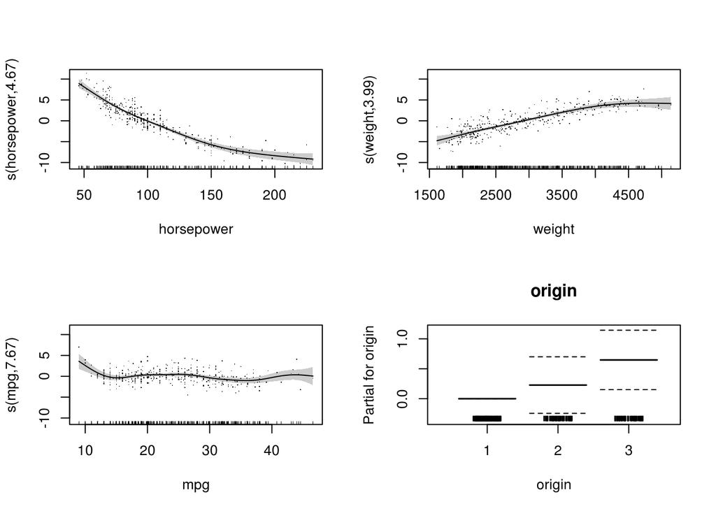

```r
plot(gam_1, scheme = 1, page = 1, residuals = T, all.terms = T)
```

Wnioski: - im więcej koni tym mniejsze przyspieszenie, - wraz ze wzrostem wagi przyspieszenie wzrasta, ale tylko do pewnego momentu, - zużycie paliwa raczej nie wpłwa na przyspieszenie, - najlepsze przyspieszenie mają japonskie samochody.

Dla porownania zbuduje model liniowy z tych samych zmiennych:

```r
liniowy <- lm(data = dataset,
              formula = acceleration ~ horsepower + weight  + mpg  + origin)
liniowy %>% summary
```

```
##
## Call:
## lm(formula = acceleration ~ horsepower + weight + mpg + origin,
##     data = dataset)
##
## Residuals:
##     Min      1Q  Median      3Q     Max
## -4.0072 -1.0873 -0.2261  0.8815  7.0998
##
## Coefficients:
##              Estimate Std. Error t value Pr(>|t|)
## (Intercept) 18.106024   1.021704  17.721   <2e-16 ***
## horsepower  -0.093892   0.004747 -19.781   <2e-16 ***
## weight       0.002423   0.000251   9.651   <2e-16 ***
## mpg         -0.005415   0.021323  -0.254   0.7997
## origin2      0.505918   0.269349   1.878   0.0611 .
## origin3      0.345645   0.279555   1.236   0.2171
## ---
## Signif. codes:  0 '***' 0.001 '**' 0.01 '*' 0.05 '.' 0.1 ' ' 1
##
## Residual standard error: 1.744 on 386 degrees of freedom
## Multiple R-squared:  0.6057, Adjusted R-squared:  0.6006
## F-statistic: 118.6 on 5 and 386 DF,  p-value: < 2.2e-16
```

Porownanie modeli

```r
gcv_lin <- mean(liniowy$residuals^2) / (1-7/(dataset %>% nrow())^2)
kryteria <- data_frame("Model" = c("GAM", "Liniowy"),
                       "AIC" = c(AIC(gam_1), AIC(liniowy)),
                       GCV = c(gam_1$gcv.ubre, gcv_lin))
kryteria
```

```
## # A tibble: 2 x 3
##   Model     AIC   GCV
##   <chr>   <dbl> <dbl>
## 1 GAM     1438.  2.29
## 2 Liniowy 1556.  2.99
```

Widzimy, ze zarowno kryterium Akaike jak i GCV sa mniejsze dla modelu GAM.

# Drzewo

```r
library(tree)
library(rpart)
library(rpart.plot)
```

```r
drzewo <- rpart(data = dataset,
               origin ~.-name-displacement)
drzewo %>% summary
```

```
## Call:
## rpart(formula = origin ~ . - name - displacement, data = dataset)
##   n= 392
##
##           CP nsplit rel error    xerror       xstd
## 1 0.09523810      0 1.0000000 1.0000000 0.06520507
## 2 0.08843537      2 0.8095238 0.9455782 0.06443284
## 3 0.07482993      3 0.7210884 0.8503401 0.06276973
## 4 0.05442177      4 0.6462585 0.8367347 0.06249832
## 5 0.04081633      5 0.5918367 0.7891156 0.06147849
## 6 0.01700680      6 0.5510204 0.7210884 0.05982402
## 7 0.01360544      8 0.5170068 0.7006803 0.05927986
## 8 0.01000000     12 0.4557823 0.6802721 0.05871257
##
## Variable importance
##       weight   horsepower          mpg    cylinders acceleration
##           23           22           19           17           12
##         year
##            8
##
## Node number 1: 392 observations,    complexity param=0.0952381
##   predicted class=1  expected loss=0.375  P(node) =1
##     class counts:   245    68    79
##    probabilities: 0.625 0.173 0.202
##   left son=2 (186 obs) right son=3 (206 obs)
##   Primary splits:
##       cylinders    < 5.5    to the right, improve=54.83945, (0 missing)
##       weight       < 2562.5 to the right, improve=48.11619, (0 missing)
##       mpg          < 21.05  to the left,  improve=41.85343, (0 missing)
##       horsepower   < 78.5   to the right, improve=36.37880, (0 missing)
##       acceleration < 13.45  to the left,  improve=13.31136, (0 missing)
##   Surrogate splits:
##       weight       < 2895   to the right, agree=0.934, adj=0.860, (0 split)
##       mpg          < 21.05  to the left,  agree=0.908, adj=0.806, (0 split)
##       horsepower   < 97.5   to the right, agree=0.880, adj=0.747, (0 split)
##       acceleration < 13.75  to the left,  agree=0.699, adj=0.366, (0 split)
##       year         < 79.5   to the left,  agree=0.625, adj=0.210, (0 split)
##
## Node number 2: 186 observations
##   predicted class=1  expected loss=0.05376344  P(node) =0.4744898
```

[output cut: 223 more lines]

```
##
## Node number 101: 9 observations
##   predicted class=3  expected loss=0.3333333  P(node) =0.02295918
##     class counts:     1     2     6
##    probabilities: 0.111 0.222 0.667
##
## Node number 200: 16 observations
##   predicted class=2  expected loss=0.375  P(node) =0.04081633
##     class counts:     6    10     0
##    probabilities: 0.375 0.625 0.000
##
## Node number 201: 16 observations
##   predicted class=1  expected loss=0.5625  P(node) =0.04081633
##     class counts:     7     4     5
##    probabilities: 0.438 0.250 0.313
```

```r
drzewo
```

```
## n= 392
##
## node), split, n, loss, yval, (yprob)
##       * denotes terminal node
##
##   1) root 392 147 1 (0.62500000 0.17346939 0.20153061)
##     2) cylinders>=5.5 186  10 1 (0.94623656 0.02150538 0.03225806) *
##     3) cylinders< 5.5 206 133 3 (0.33495146 0.31067961 0.35436893)
##       6) mpg< 30.95 129  77 1 (0.40310078 0.37984496 0.21705426)
##        12) horsepower< 92.5 98  49 1 (0.50000000 0.37755102 0.12244898)
##          24) weight>=2305 48  13 1 (0.72916667 0.25000000 0.02083333)
##            48) weight< 2953.5 40   6 1 (0.85000000 0.12500000 0.02500000) *
##            49) weight>=2953.5 8   1 2 (0.12500000 0.87500000 0.00000000) *
##          25) weight< 2305 50  25 2 (0.28000000 0.50000000 0.22000000)
##            50) weight>=1952.5 41  25 2 (0.34146341 0.39024390 0.26829268)
##             100) horsepower< 87 32  18 2 (0.40625000 0.43750000 0.15625000)
##               200) year< 74.5 16   6 2 (0.37500000 0.62500000 0.00000000) *
##               201) year>=74.5 16   9 1 (0.43750000 0.25000000 0.31250000) *
##             101) horsepower>=87 9   3 3 (0.11111111 0.22222222 0.66666667) *
##            51) weight< 1952.5 9   0 2 (0.00000000 1.00000000 0.00000000) *
##        13) horsepower>=92.5 31  15 3 (0.09677419 0.38709677 0.51612903)
##          26) horsepower>=97.5 14   4 2 (0.14285714 0.71428571 0.14285714) *
##          27) horsepower< 97.5 17   3 3 (0.05882353 0.11764706 0.82352941) *
##       7) mpg>=30.95 77  32 3 (0.22077922 0.19480519 0.58441558)
##        14) acceleration< 16.3 36  22 3 (0.36111111 0.25000000 0.38888889)
##          28) year< 79.5 11   5 1 (0.54545455 0.36363636 0.09090909) *
##          29) year>=79.5 25  12 3 (0.28000000 0.20000000 0.52000000) *
##        15) acceleration>=16.3 41  10 3 (0.09756098 0.14634146 0.75609756)
##          30) acceleration>=19.3 9   4 2 (0.11111111 0.55555556 0.33333333) *
##          31) acceleration< 19.3 32   4 3 (0.09375000 0.03125000 0.87500000) *
```

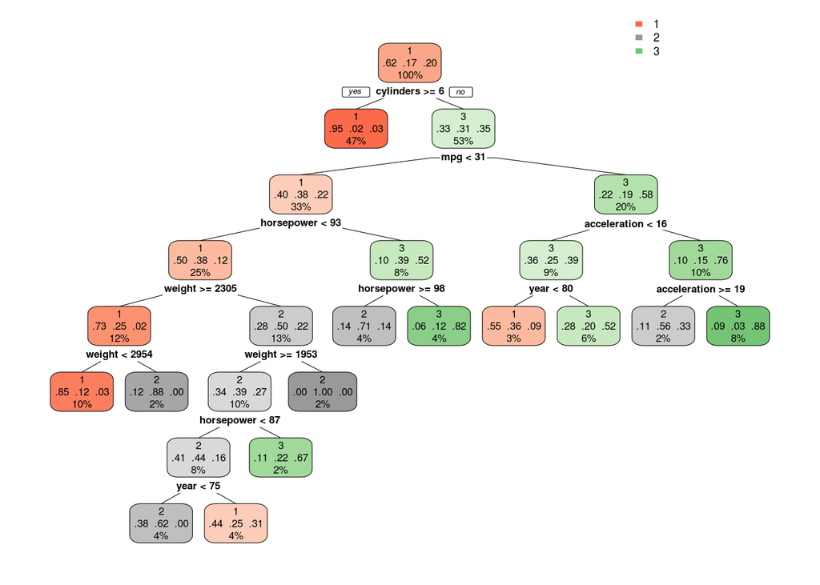

```r
rpart.plot(drzewo, type = 2,
           fallen.leaves = F)
```

Widzimy, ze pierwszy podzial dotyczy liczby cylindrow. Jezeli auto ma ich więcej niż 5, to automatycznie zostaje zakwalifikowane do samochodow amerykanskich. Co ciekawe, analizujac powyzsze drzewo mozna pomyslec, ze amerykanskie auta maja wieksze spalanie (mpg < 31) i wydaje sie to byc dobrym oddaniem rzeczywistosci.